# PYR - cvičení vizualizace

## Instrukce

Na základě zadání vypracujte report (Jypyter nebo R Notebook) S odpověďmi na dílčí úlohy níže. Na místech, kde je to vhodné, prezentujte vlastní řešení vypracované v jazycích Python a R. Výsledný dokument ve formátu html nebo ipynb nahrajte spolu se zdrojovými kódy na Moodle přiřazený k tomuto kurzu (neváhejte nahrát celou pracovní složku včetně zdrojových dat).

Pro vypracování využijte dataset **Student Mental Health Analysis During Online Learning.csv**

## Úloha 1: Popis dat

Pro každou proměnnou v datasetu:

1. Určete její typ (např. nominální, ordinální, intervalová, poměrová).
2. Uveďte, jaké typy grafické vizualizace jsou pro tuto proměnnou vhodné (např. sloupcový graf, histogram, krabicový graf, bodový graf apod.) a stručně vysvětlete proč.

## Úloha 2: Rozdělení proměnné „Stress Level“

1. Vysvětlete, který graf (A/B) je korektnější a proč?
2. Pro oba grafy spočítejte *Lie factor*.
3. Jak by vypadal korektní redesign? Vytvořte vlastní verzi správné vizualizace.

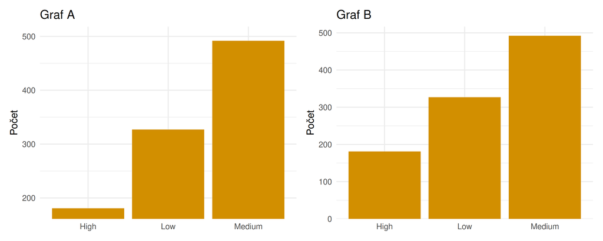

# Úloha 3: Struktura „Academic Performance Change“ podle „Education Level“

**Otázky:**  
1) Který graf je vhodnější pro srovnání **struktury** mezi úrovněmi vzdělání?  
2) Jak jasněji popsat legendu a pořadí kategorií? Vytvořte vlastní správnou vizualizaci.

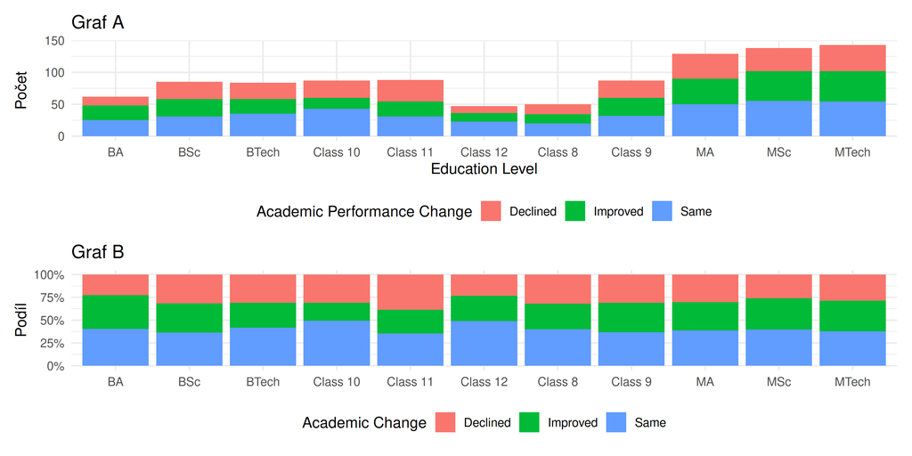

# Úloha 4: Heatmapa: Screen Time × Sleep Duration (binning) a volba palety

**Otázky:**  
1) Která z uvedených barevných škál je vhodnější pro vizualizace daných proměnných a proč?  
2) Jak byste změnili popisky os, aby bylo jasné, že jde o **binované** intervaly? Vytvořte vlastní lepší variantu.

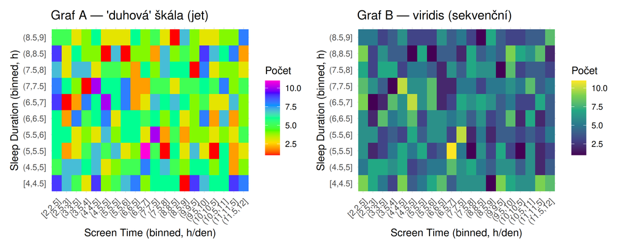

```r
# Připrav binned matici počtů
bins_x <- pretty(mh$`Screen Time (hrs/day)`, n = 15)
bins_y <- pretty(mh$`Sleep Duration (hrs)`,   n = 15)

heat_df <- mh %>%
  mutate(
    scr_bin = cut(`Screen Time (hrs/day)`, breaks = bins_x, include.lowest = TRUE),
    slp_bin = cut(`Sleep Duration (hrs)`,   breaks = bins_y, include.lowest = TRUE)
  ) %>%
  count(scr_bin, slp_bin)

pA <- ggplot(heat_df, aes(x = scr_bin, y = slp_bin, fill = n)) +
  geom_tile() +
  scale_fill_gradientn(colours = grDevices::rainbow(7)) +  # „duha“
  theme(axis.text.x = element_text(angle = 45, hjust = 1)) +
  labs(title = "Graf A — 'duhová' škála (jet)", x = "Screen Time (binned, h/den)",
       y = "Sleep Duration (binned, h)", fill = "Počet")

pB <- ggplot(heat_df, aes(x = scr_bin, y = slp_bin, fill = n)) +
  geom_tile() +
  scale_fill_viridis_c() +  # perceptuální, monotónní luminance
  theme(axis.text.x = element_text(angle = 45, hjust = 1)) +
  labs(title = "Graf B — viridis (sekvenční)", x = "Screen Time (binned, h/den)",
       y = "Sleep Duration (binned, h)", fill = "Počet")

pA + pB
```

# Úloha 5: Odchylka spánku od doporučených 7 h

**Otázky:**  
1) Která z uvedených barevných škál je vhodnější pro vizualizace daných proměnných a proč?  
2) Jak bys anotovali „bezpečnou“ zónu (např. ±0.5 h)? Vytvořte vlastní upravenou variantu správné vizualizace.

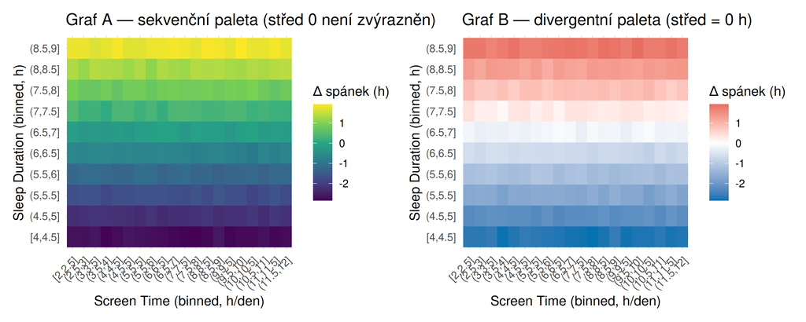

# Úloha 6: „High“ stres podle Education Level

**Otázky:**  
1) Který graf je férovější pro srovnání napříč „Education Level“ a proč?  
2) Doplňte chybu/nejistotu výpočtu do vlastní upravené vizualizace.

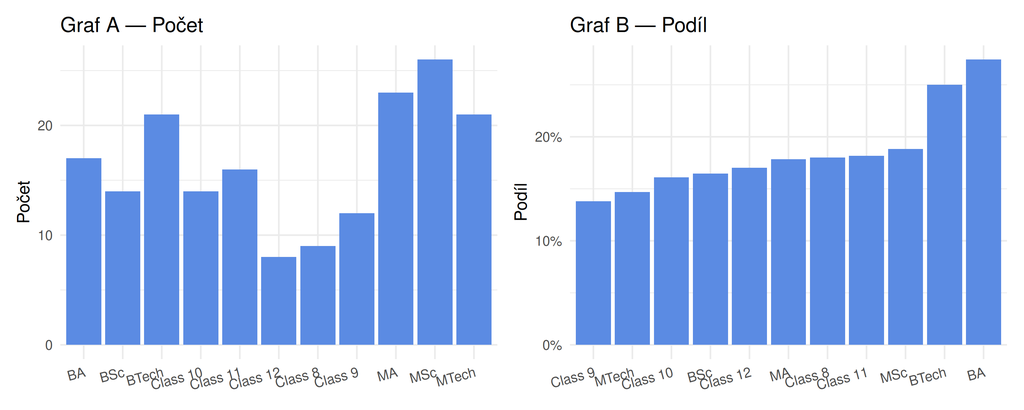

```r
high_df <- mh %>%
  mutate(high = `Stress Level` == "High") %>%
  count(`Education Level`, high) %>%
  group_by(`Education Level`) %>%
  mutate(total = sum(n), prop = n/total) %>%
  ungroup()

pA <- high_df %>%
  filter(high) %>%
  ggplot(aes(x = `Education Level`, y = n)) +
  geom_col(fill = "#5b8be3") +
  labs(title = "Graf A — Počet",
       y = "Počet", x = NULL) +
  theme(axis.text.x = element_text(angle = 15, hjust = 1))

pB <- high_df %>%
  filter(high) %>%
  ggplot(aes(x = fct_reorder(`Education Level`, prop), y = prop)) +
  geom_col(fill = "#5b8be3") +
  scale_y_continuous(labels = percent_format()) +
  labs(title = "Graf B — Podíl", y = "Podíl", x = NULL) +
  theme(axis.text.x = element_text(angle = 15, hjust = 1))

pA + pB
```